# Assignment 10

MJKelleher

March 18, 2018

## 1) Mental Health Clinics

### (a.) [Refer to SAMHDA Website](https://datafiles.samhsa.gov/study-dataset/national-mental-health-services-survey-2015-n-mhss-2015-ds0001-nid17098) to download the R dataset and [review the codebook](http://samhda.s3-us-gov-west-1.amazonaws.com/s3fs-public/field-uploads-protected/studies/N-MHSS-2015/N-MHSS-2015-datasets/N-MHSS-2015-DS0001/N-MHSS-2015-DS0001-info/N-MHSS-2015-DS0001-info-codebook.pdf) to get the variable names. Open the dataset for Analysis.

```r
rda_file <- "data/N-MHSS-2015-DS0001-data/N-MHSS-2015-DS0001-data-r.rda"
varname <- "mh2015_puf"

if (! exists("mh2015_puf")) {
    sprintf("Loading dataframe %s from file %s.", varname, rda_file)
    load(file = rda_file)
}
```

### (b.) List state abbreviations without their counts.

```r
#   Get the unique list
#   Convert to character from Factor
#   Make sure the list is sorted
getStates <- function(the_vector){
    states <- sort( as.character( unique(the_vector) ) )
#   Trim leading and trailing whitespace
    states <- lapply(states, trimws)
}

states <- getStates(mh2015_puf$LST)
head(states, 5)
```

```
## [[1]]
## [1] "AK"
##
## [[2]]
## [1] "AL"
##
## [[3]]
## [1] "AR"
##
## [[4]]
## [1] "AS"
##
## [[5]]
## [1] "AZ"
```

```r
tail(states, 5)
```

```
## [[1]]
## [1] "VT"
##
## [[2]]
## [1] "WA"
##
## [[3]]
## [1] "WI"
##
## [[4]]
## [1] "WV"
##
## [[5]]
## [1] "WY"
```

```r
length(states)
```

```
## [1] 55
```

### (c.) Filter the data, removing all non Mainland rows from the dataset. DC can remain.

```r
    non_mainland_states <- c('AK', 'AS', 'GU', 'HI', 'PR', 'VI')
#   States to be filtered from Dataframe
#   Convert the Factor to a Staring
#   Trim the leading and trailing whitespace from the String
#   Select only those rows not in the invalid_states list
    mh2015_filtered <- filter(mh2015_puf, ! (trimws(as.character(LST)) %in% non_mainland_states) )

    sprintf("Count of original dataset: %d, count of filtered dataset: %d", nrow(mh2015_puf), nrow(mh2015_filtered))
```

```
## [1] "Count of original dataset: 12826, count of filtered dataset: 12568"
```

### (d.) Produce a ggplot barchart of the State, varying the color by state. Include title and axis labels.

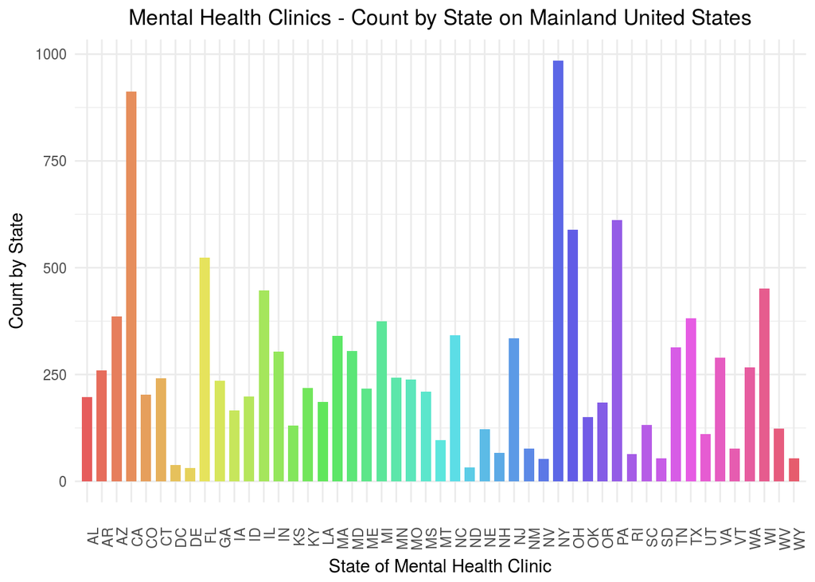

```r
    mainland_states <- getStates(mh2015_filtered$LST)
    colors = rainbow(length(mainland_states), s=.6, v=.9)

    plotinfo <- data.frame(mainland_states, colors)


    q01_d_plot <- ggplot(data=mh2015_filtered, aes(x=LST)) +
         geom_bar(stat="count", width=0.7, fill=colors)+
         theme_minimal() +
         theme(plot.title = element_text(hjust=0.5)) +
         theme(axis.text.x = element_text(angle = 90, hjust = 1)) +
         labs(title="Mental Health Clinics - Count by State on Mainland United States") +
         labs(x="State of Mental Health Clinic") +
         labs (y="Count by State") +
         scale_x_discrete(expand = c(0.01,0)) +
         scale_fill_manual(values=colors)

    grid::grid.draw(q01_d_plot)
```

## 2) Cleaning and New Features

### (a.)

```r
filename <- "statesize.csv"
dataURL <- paste(dbxroot, filename, sep="");
statesize <- read.csv(url(dataURL));

sprintf("Statesize DF row count is %d", nrow(statesize))
```

```
## [1] "Statesize DF row count is 50"
```

```r
mh2015_merge <- merge(mh2015_filtered, statesize)

cnt_orig <- nrow(mh2015_filtered)
cnt_merge <- nrow(mh2015_merge)
merge_fact <- cnt_merge / cnt_orig

length(which(mh2015_filtered$CASEID == 201500001))
```

```
## [1] 1
```

```r
length(which(mh2015_merge$CASEID == 201500001))
```

```
## [1] 50
```

```r
sprintf("%d rows in Original DF, %d rows in Merged DF, Merged DF increased by factor of %.3f", cnt_orig, cnt_merge, merge_fact)
```

```
## [1] "12568 rows in Original DF, 628400 rows in Merged DF, Merged DF increased by factor of 50.000"
```

#### For every forw in the statesize Dataframe, all rows from the original Filtered Dataframe from #1c are included. Because statesize has 50 rows, we have exactly `50*SizeOf(mh2015_filtered)` number of rows in the merged dataset. My guess is that while both DF’s have the State Data, because they are Factors and not character data, even though from a character data perspective there is a match, they are NOT a match because the Factors are Unique.

### (b.) Correct the data mismatch between the dataframe in #1c and the statesize dataframe, and merge.

```r
# Add Character versions of the State field
# Looks like Factors are unique across 2 different Dataframe even
#   though byte for byte they are equal
#
statesize$STATE <- trimws(as.character(statesize$Abbrev))
mh2015_filtered$STATE <- trimws(as.character(mh2015_filtered$LST))

# Merge
mh2015_merge <- merge(mh2015_filtered, statesize, by="STATE")

# Cross Validation#
cnt_orig <- nrow(mh2015_filtered)
cnt_merge <- nrow(mh2015_merge)
merge_fact <- cnt_merge / cnt_orig

sprintf("Second Merge:  %d rows in Original DF, %d rows in Merged DF, Merged DF increased by factor of %.3f", cnt_orig, cnt_merge, merge_fact)
```

```
## [1] "Second Merge:  12568 rows in Original DF, 12530 rows in Merged DF, Merged DF increased by factor of 0.997"
```

```r
# Find out why we "lost" some data
unique_states <- unique(statesize$STATE)

missing <- filter(mh2015_filtered, !(STATE %in% unique_states))

sprintf("Here are the states contained in the dataframe from #1c, but not contained in the dataframe statesize")
```

```
## [1] "Here are the states contained in the dataframe from #1c, but not contained in the dataframe statesize"
```

```r
unique(missing$STATE)
```

```
## [1] "DC"
```

### (c.) Calculate a new variable in your combined data.frame() which indicates the VA hospitals per thousand square miles.

```r
mh2015_merge$HospitalPer_1k_Miles <- 0.0

statecount <- data.frame(matrix(ncol = 4, nrow = 0))
colnames(statecount) <- c("STATE", "HospitalPer_1k_Miles", "SqMiles", "COUNT")

for (rowcnt in 1:nrow(statesize)) {
    # Get the count of Hospitals per state
    totalcount <- length( which( mh2015_merge$STATE == statesize[rowcnt,]$STATE ) )
    # calculate hospitals per 1000 square miles per state
    per1k <- (totalcount * 1000) / statesize[rowcnt,]$SqMiles
    # populate the merge dataframe
    mh2015_merge$HospitalPer_1k_Miles[mh2015_merge$STATE == statesize[rowcnt,]$STATE] <- per1k
}
```

### (d.) GGPlot with VA’s per 1000 Square Miles by Region, sorted by Descending Bar Plot

#### I ran out of time trying to figure out how to do a legend.

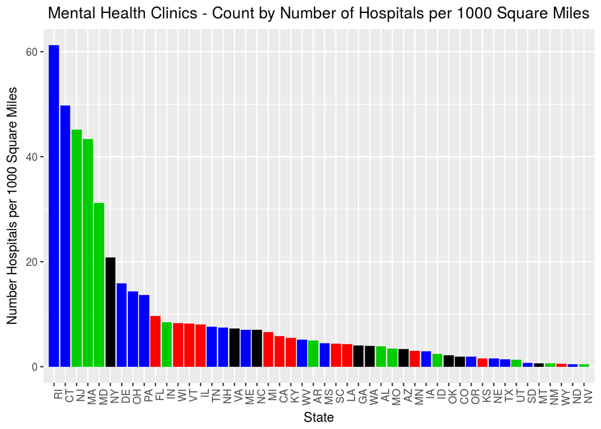

```r
    # Select unique by State, Region and HospitalPer_1k_Miles
    agg <- distinct(mh2015_merge, STATE, Region, HospitalPer_1k_Miles)
    agg$Color <- 0

    # get the Unique Regions
    regions <- as.character( unique(agg$Region) )
    # get a Unique Color for Each Region
    uniq_colors = rainbow(length(regions), s=.6, v=.9)
    # Create a DF to match up with agg
    colors <- data.frame(regions, uniq_colors)
    colnames(colors) <- c("Region", "Color")

    # Empty colors list for the plot
    # colors <- vector("list", length = nrow(agg))

    for (rowcnt in 1:nrow(agg)) {
        colorIndex <- which(colors$Region == agg[rowcnt,]$Region)
        agg[rowcnt,]$Color <- colors[colorIndex,]$Color
    }

    #colors$Color
    q02_d_plot <- ggplot(data=agg, aes(x= reorder(STATE, -HospitalPer_1k_Miles), y=HospitalPer_1k_Miles)) +
         geom_col(fill=agg$Color) +
         #theme_minimal() +
         theme(plot.title = element_text(hjust=0.5)) +
         theme(axis.text.x = element_text(angle = 90, hjust = 1)) +
         labs(title="Mental Health Clinics - Count by Number of Hospitals per 1000 Square Miles") +
         labs(x="State", y="Number Hospitals per 1000 Square Miles") +
         scale_x_discrete(expand = c(0.01,0))

    grid::grid.draw(q02_d_plot)
```

### (e.1) What patterns do you see?

#### A large portion of the total hospitals are contained in a few states.

### (e.2) By this metric, is there any region that seems relatively high for VA medical centers per thousand square miles?

#### The eastern seaboard seems to be high in the count of hospitals.

### (e.3) How about low?

#### Total count per thousand is small west of a certain point, with the exception of a couple states.

### (e.4) Given these data, what advice might you give your boss before you start modeling (and why)?

#### There are some states that seem to be low, and I would double check the aggregate data to make sure the counts are correct. or possibly make sure responses were not lost, or not reported. If data is getting dropped, this would bias the model.

## [Upload to GitHub](https://github.com/allthebits/mjk-msds6306)

- Files for this homework (Unit 10) are in this folder: **homework/unit_10**
- [RMD File](https://github.com/allthebits/mjk-msds6306/blob/master/homework/unit_10/homework_submission.Rmd)
- [HTML Version of Assignment 10](http://htmlpreview.github.io/?https://raw.githubusercontent.com/allthebits/mjk-msds6306/master/homework/unit_10/homework_submission.html) - It’s the same exact content as this page, except served from GitHub